# WaveformAnalysis

波形数据处理步骤：

1. 移动平均算法减少噪声引起的涨落。

$y[n]=\frac{1}{n}\sum_{i=-N+1}^{0} x[n+i]$ 公式简化后$y[n+1]=y[n]+\frac{x[n+1]-x[n-N+1]}{N}$

移动平均的点数N一般取60-100，建议取80。可以通过模拟查看取不同值时上升沿的效果。

2. 基线修正(基线归零)。

把波形的前100个点取平均，波形的每个点减去这个平均值。 公式为$x[k]=raw[k]-\frac{1}{100}\sum_{0}^{99} raw[i]$

3. 极零修正(把信号通过前放变成的指数衰减信号还原回去)。有的算法可以不进行这步操作。

$v'[n] = v'[n-1]+v[n]-v[n-1]e^{-\frac{1}{\tau}}$

4. 梯形算法。梯形算法比$CR-(RC)^n$算法好，这是因为$CR-(RC)^n$算法回到基线会有很长的衰减时间(衰减信号不能很好的回到基线)，而梯形算法信号衰减后可以回到基线，提取的脉冲高度更加准确的同时也有效的减少了堆积事件。

$s[k]=s[k-1]+v'[k]-v'[K-L]+v'[K-2*L-G]-v'[K-L-G]$

5. 提取脉冲幅度和上升时间。有的时候不同粒子在幅度0-0.4的上升时间差别很大，就提取0-0.4E的上升时间区分不同粒子。正常上升时间是指最大幅度的0.1-0.9的时间。

现在对上面公式进行验证。  
1.产生模拟衰减信号

```python
Double_t tau=500;//衰减时间
 Double_t theta[3];
    Double_t r[3]={0.01,0.025,0.05};//上升时间
    TGraph *gv[3],*gvc[3],*gtr[3];
    for(int i=0;i<3;i++) {
        gv[i]=new TGraph();
        gvc[i]=new TGraph();
        gtr[i]=new TGraph();
        gv[i]->SetLineColor(i+2);
        gvc[i]->SetLineColor(i+2);
        gtr[i]->SetLineColor(i+2);
        gv[i]->SetMarkerColor(i+2);
        gvc[i]->SetMarkerColor(i+2);
        gtr[i]->SetMarkerColor(i+2);
    }
    TCanvas *c1=new TCanvas();
    TCanvas *c2=new TCanvas();
    TCanvas *c3=new TCanvas();
```

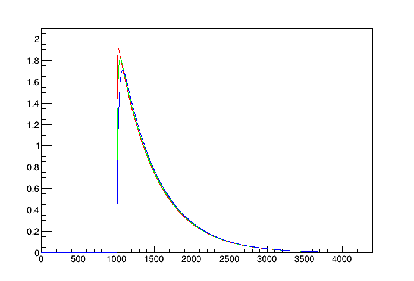

```python
for(int i=0;i<3;i++) {
        theta[i]=r[i]*tau;
        for(int k=0;k<4000;k++) {
            double vv;
            if(k>=1000) {
                vv=1000/(tau-theta[i])*(TMath::Exp(-(k-1000)/tau)-TMath::Exp(-(k-1000)/theta[i]));
            }
            else vv=0;
            gv[i]->SetPoint(k,k,vv);
        }
    }
    c1->cd();
    gv[0]->Draw();
    gv[1]->Draw("same");
    gv[2]->Draw("same");
    c1->Draw();
```

这个信号不用进行移动平均和基线恢复，直接进行极零修正。

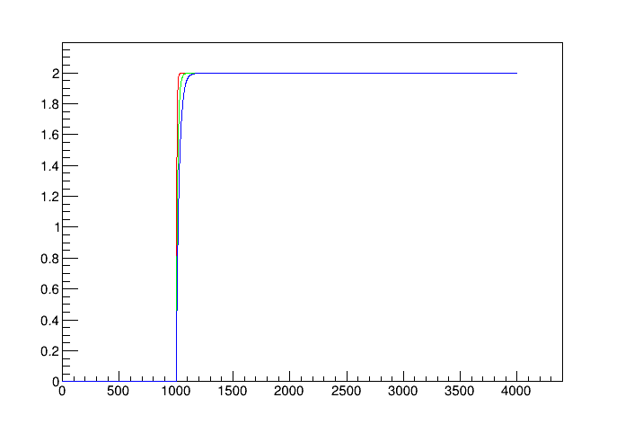

```python
for(int i=0;i<3;i++) {
    for(int k=0;k<4000;k++) {
        if(k==0) gvc[i]->SetPoint(k,k,0);
        else{
                double s,x1,x2;
                s=gvc[i]->Eval(k-1);
                x1=gv[i]->Eval(k);
                // x2=gv[i]->Eval(k-1)*(1-1/tau);
                x2=gv[i]->Eval(k-1)*(TMath::Exp(-1/tau));
                gvc[i]->SetPoint(k,k,s+x1-x2);
            }
        }
    }
    c2->cd();
    gvc[0]->Draw();
    gvc[1]->Draw("same");
    gvc[2]->Draw("same");
    c2->Draw();
```

梯形算法

```python
double L=400;
double G=200;
```

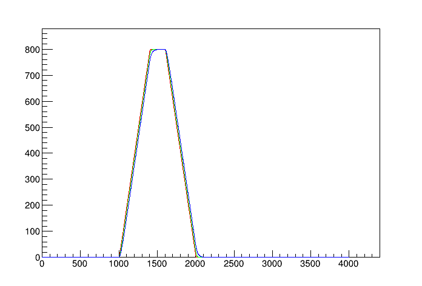

```python
for(int i=0;i<3;i++) {
        for(int k=0;k<4000;k++){
            if(k<2*L+G) gtr[i]->SetPoint(k,k,0);
            else {
                double s,x1,x2,x3,x4;
                s=gtr[i]->Eval(k-1);
                x1=gvc[i]->Eval(k);
                x2=gvc[i]->Eval(k-L);
                x3=gvc[i]->Eval(k-L-G);
                x4=gvc[i]->Eval(k-2*L-G);
                gtr[i]->SetPoint(k,k,s+x1-x2-x3+x4);
            }
        }
    }
    c3->cd();
    gtr[0]->Draw();
    gtr[1]->Draw("same");
    gtr[2]->Draw("same");
    c3->Draw();
```

现在验证不用极令恢复的梯形算法

```python
Int_t kk = 200;
Int_t ll = 400;
Int_t mm = 2500;
```